# Project: TMDB Movies Data

|  | id | imdb_id | popularity | budget | revenue | original_title | cast | homepage | director | tagline | ... | overview | runtime | genres | production_companies | release_date | vote_count | vote_average | release_year | budget_adj | revenue_adj |
| --- | --- | --- | --- | --- | --- | --- | --- | --- | --- | --- | --- | --- | --- | --- | --- | --- | --- | --- | --- | --- | --- |
| 0 | 135397 | tt0369610 | 32.985763 | 150000000 | 1513528810 | Jurassic World | Chris Pratt\|Bryce Dallas Howard\|Irrfan Khan\|Vi... | http://www.jurassicworld.com/ | Colin Trevorrow | The park is open. | ... | Twenty-two years after the events of Jurassic ... | 124 | Action\|Adventure\|Science Fiction\|Thriller | Universal Studios\|Amblin Entertainment\|Legenda... | 6/9/15 | 5562 | 6.5 | 2015 | 1.379999e+08 | 1.392446e+09 |
| 1 | 76341 | tt1392190 | 28.419936 | 150000000 | 378436354 | Mad Max: Fury Road | Tom Hardy\|Charlize Theron\|Hugh Keays-Byrne\|Nic... | http://www.madmaxmovie.com/ | George Miller | What a Lovely Day. | ... | An apocalyptic story set in the furthest reach... | 120 | Action\|Adventure\|Science Fiction\|Thriller | Village Roadshow Pictures\|Kennedy Miller Produ... | 5/13/15 | 6185 | 7.1 | 2015 | 1.379999e+08 | 3.481613e+08 |
| 2 | 262500 | tt2908446 | 13.112507 | 110000000 | 295238201 | Insurgent | Shailene Woodley\|Theo James\|Kate Winslet\|Ansel... | http://www.thedivergentseries.movie/#insurgent | Robert Schwentke | One Choice Can Destroy You | ... | Beatrice Prior must confront her inner demons ... | 119 | Adventure\|Science Fiction\|Thriller | Summit Entertainment\|Mandeville Films\|Red Wago... | 3/18/15 | 2480 | 6.3 | 2015 | 1.012000e+08 | 2.716190e+08 |
| 3 | 140607 | tt2488496 | 11.173104 | 200000000 | 2068178225 | Star Wars: The Force Awakens | Harrison Ford\|Mark Hamill\|Carrie Fisher\|Adam D... | http://www.starwars.com/films/star-wars-episod... | J.J. Abrams | Every generation has a story. | ... | Thirty years after defeating the Galactic Empi... | 136 | Action\|Adventure\|Science Fiction\|Fantasy | Lucasfilm\|Truenorth Productions\|Bad Robot | 12/15/15 | 5292 | 7.5 | 2015 | 1.839999e+08 | 1.902723e+09 |
| 4 | 168259 | tt2820852 | 9.335014 | 190000000 | 1506249360 | Furious 7 | Vin Diesel\|Paul Walker\|Jason Statham\|Michelle ... | http://www.furious7.com/ | James Wan | Vengeance Hits Home | ... | Deckard Shaw seeks revenge against Dominic Tor... | 137 | Action\|Crime\|Thriller | Universal Pictures\|Original Film\|Media Rights ... | 4/1/15 | 2947 | 7.3 | 2015 | 1.747999e+08 | 1.385749e+09 |
| 5 | 281957 | tt1663202 | 9.110700 | 135000000 | 532950503 | The Revenant | Leonardo DiCaprio\|Tom Hardy\|Will Poulter\|Domhn... | http://www.foxmovies.com/movies/the-revenant | Alejandro González Iñárritu | (n. One who has returned, as if from the dead.) | ... | In the 1820s, a frontiersman, Hugh Glass, sets... | 156 | Western\|Drama\|Adventure\|Thriller | Regency Enterprises\|Appian Way\|CatchPlay\|Anony... | 12/25/15 | 3929 | 7.2 | 2015 | 1.241999e+08 | 4.903142e+08 |
| 6 | 87101 | tt1340138 | 8.654359 | 155000000 | 440603537 | Terminator Genisys | Arnold Schwarzenegger\|Jason Clarke\|Emilia Clar... | http://www.terminatormovie.com/ | Alan Taylor | Reset the future | ... | The year is 2029. John Connor, leader of the r... | 125 | Science Fiction\|Action\|Thriller\|Adventure | Paramount Pictures\|Skydance Productions | 6/23/15 | 2598 | 5.8 | 2015 | 1.425999e+08 | 4.053551e+08 |
| 7 | 286217 | tt3659388 | 7.667400 | 108000000 | 595380321 | The Martian | Matt Damon\|Jessica Chastain\|Kristen Wiig\|Jeff ... | http://www.foxmovies.com/movies/the-martian | Ridley Scott | Bring Him Home | ... | During a manned mission to Mars, Astronaut Mar... | 141 | Drama\|Adventure\|Science Fiction | Twentieth Century Fox Film Corporation\|Scott F... | 9/30/15 | 4572 | 7.6 | 2015 | 9.935996e+07 | 5.477497e+08 |
| 8 | 211672 | tt2293640 | 7.404165 | 74000000 | 1156730962 | Minions | Sandra Bullock\|Jon Hamm\|Michael Keaton\|Allison... | http://www.minionsmovie.com/ | Kyle Balda\|Pierre Coffin | Before Gru, they had a history of bad bosses | ... | Minions Stuart, Kevin and Bob are recruited by... | 91 | Family\|Animation\|Adventure\|Comedy | Universal Pictures\|Illumination Entertainment | 6/17/15 | 2893 | 6.5 | 2015 | 6.807997e+07 | 1.064192e+09 |
| 9 | 150540 | tt2096673 | 6.326804 | 175000000 | 853708609 | Inside Out | Amy Poehler\|Phyllis Smith\|Richard Kind\|Bill Ha... | http://movies.disney.com/inside-out | Pete Docter | Meet the little voices inside your head. | ... | Growing up can be a bumpy road, and it's no ex... | 94 | Comedy\|Animation\|Family | Walt Disney Pictures\|Pixar Animation Studios\|W... | 6/9/15 | 3935 | 8.0 | 2015 | 1.609999e+08 | 7.854116e+08 |
| 10 | 206647 | tt2379713 | 6.200282 | 245000000 | 880674609 | Spectre | Daniel Craig\|Christoph Waltz\|Léa Seydoux\|Ralp... | http://www.sonypictures.com/movies/spectre/ | Sam Mendes | A Plan No One Escapes | ... | A cryptic message from Bond’s past sends him... | 148 | Action\|Adventure\|Crime | Columbia Pictures\|Danjaq\|B24 | 10/26/15 | 3254 | 6.2 | 2015 | 2.253999e+08 | 8.102203e+08 |
| 11 | 76757 | tt1617661 | 6.189369 | 176000003 | 183987723 | Jupiter Ascending | Mila Kunis\|Channing Tatum\|Sean Bean\|Eddie Redm... | http://www.jupiterascending.com | Lana Wachowski\|Lilly Wachowski | Expand your universe. | ... | In a universe where human genetic material is ... | 124 | Science Fiction\|Fantasy\|Action\|Adventure | Village Roadshow Pictures\|Dune Entertainment\|A... | 2/4/15 | 1937 | 5.2 | 2015 | 1.619199e+08 | 1.692686e+08 |
| 12 | 264660 | tt0470752 | 6.118847 | 15000000 | 36869414 | Ex Machina | Domhnall Gleeson\|Alicia Vikander\|Oscar Isaac\|S... | http://exmachina-movie.com/ | Alex Garland | There is nothing more human than the will to s... | ... | Caleb, a 26 year old coder at the world's larg... | 108 | Drama\|Science Fiction | DNA Films\|Universal Pictures International (UP... | 1/21/15 | 2854 | 7.6 | 2015 | 1.379999e+07 | 3.391985e+07 |
| 13 | 257344 | tt2120120 | 5.984995 | 88000000 | 243637091 | Pixels | Adam Sandler\|Michelle Monaghan\|Peter Dinklage\|... | http://www.pixels-movie.com/ | Chris Columbus | Game On. | ... | Video game experts are recruited by the milita... | 105 | Action\|Comedy\|Science Fiction | Columbia Pictures\|Happy Madison Productions | 7/16/15 | 1575 | 5.8 | 2015 | 8.095996e+07 | 2.241460e+08 |
| 14 | 99861 | tt2395427 | 5.944927 | 280000000 | 1405035767 | Avengers: Age of Ultron | Robert Downey Jr.\|Chris Hemsworth\|Mark Ruffalo... | http://marvel.com/movies/movie/193/avengers_ag... | Joss Whedon | A New Age Has Come. | ... | When Tony Stark tries to jumpstart a dormant p... | 141 | Action\|Adventure\|Science Fiction | Marvel Studios\|Prime Focus\|Revolution Sun Studios | 4/22/15 | 4304 | 7.4 | 2015 | 2.575999e+08 | 1.292632e+09 |
| 15 | 273248 | tt3460252 | 5.898400 | 44000000 | 155760117 | The Hateful Eight | Samuel L. Jackson\|Kurt Russell\|Jennifer Jason ... | http://thehatefuleight.com/ | Quentin Tarantino | No one comes up here without a damn good reason. | ... | Bounty hunters seek shelter from a raging bliz... | 167 | Crime\|Drama\|Mystery\|Western | Double Feature Films\|The Weinstein Company\|Fil... | 12/25/15 | 2389 | 7.4 | 2015 | 4.047998e+07 | 1.432992e+08 |
| 16 | 260346 | tt2446042 | 5.749758 | 48000000 | 325771424 | Taken 3 | Liam Neeson\|Forest Whitaker\|Maggie Grace\|Famke... | http://www.taken3movie.com/ | Olivier Megaton | It Ends Here | ... | Ex-government operative Bryan Mills finds his ... | 109 | Crime\|Action\|Thriller | Twentieth Century Fox Film Corporation\|M6 Film... | 1/1/15 | 1578 | 6.1 | 2015 | 4.415998e+07 | 2.997096e+08 |
| 17 | 102899 | tt0478970 | 5.573184 | 130000000 | 518602163 | Ant-Man | Paul Rudd\|Michael Douglas\|Evangeline Lilly\|Cor... | http://marvel.com/movies/movie/180/ant-man | Peyton Reed | Heroes Don't Get Any Bigger | ... | Armed with the astonishing ability to shrink i... | 115 | Science Fiction\|Action\|Adventure | Marvel Studios | 7/14/15 | 3779 | 7.0 | 2015 | 1.195999e+08 | 4.771138e+08 |
| 19 | 131634 | tt1951266 | 5.476958 | 160000000 | 650523427 | The Hunger Games: Mockingjay - Part 2 | Jennifer Lawrence\|Josh Hutcherson\|Liam Hemswor... | http://www.thehungergames.movie/ | Francis Lawrence | The fire will burn forever. | ... | With the nation of Panem in a full scale war, ... | 136 | War\|Adventure\|Science Fiction | Studio Babelsberg\|StudioCanal\|Lionsgate\|Walt D... | 11/18/15 | 2380 | 6.5 | 2015 | 1.471999e+08 | 5.984813e+08 |
| 20 | 158852 | tt1964418 | 5.462138 | 190000000 | 209035668 | Tomorrowland | Britt Robertson\|George Clooney\|Raffey Cassidy\|... | http://movies.disney.com/tomorrowland | Brad Bird | Imagine a world where nothing is impossible. | ... | Bound by a shared destiny, a bright, optimisti... | 130 | Action\|Family\|Science Fiction\|Adventure\|Mystery | Walt Disney Pictures\|Babieka\|A113 | 5/19/15 | 1899 | 6.2 | 2015 | 1.747999e+08 | 1.923127e+08 |
| 22 | 254128 | tt2126355 | 4.907832 | 110000000 | 470490832 | San Andreas | Dwayne Johnson\|Alexandra Daddario\|Carla Gugino... | http://www.sanandreasmovie.com/ | Brad Peyton | A rescue pilot survived an earthquake, this is... | ... | In the aftermath of a massive earthquake in Ca... | 114 | Action\|Drama\|Thriller | New Line Cinema\|Village Roadshow Pictures\|Warn... | 5/27/15 | 2060 | 6.1 | 2015 | 1.012000e+08 | 4.328514e+08 |
| 23 | 216015 | tt2322441 | 4.710402 | 40000000 | 569651467 | Fifty Shades of Grey | Dakota Johnson\|Jamie Dornan\|Jennifer Ehle\|Eloi... | https://www.facebook.com/fiftyshadesofgreymovie | Sam Taylor-Johnson | Are you curious? | ... | When college senior Anastasia Steele steps in ... | 125 | Drama\|Romance | Focus Features\|Trigger Street Productions\|Mich... | 2/11/15 | 1865 | 5.3 | 2015 | 3.679998e+07 | 5.240791e+08 |
| 24 | 318846 | tt1596363 | 4.648046 | 28000000 | 133346506 | The Big Short | Christian Bale\|Steve Carell\|Ryan Gosling\|Brad ... | http://www.thebigshortmovie.com/ | Adam McKay | This is a true story. | ... | The men who made millions from a global econom... | 130 | Comedy\|Drama | Paramount Pictures\|Plan B Entertainment\|Regenc... | 12/11/15 | 1545 | 7.3 | 2015 | 2.575999e+07 | 1.226787e+08 |
| 25 | 177677 | tt2381249 | 4.566713 | 150000000 | 682330139 | Mission: Impossible - Rogue Nation | Tom Cruise\|Jeremy Renner\|Simon Pegg\|Rebecca Fe... | http://www.missionimpossible.com | Christopher McQuarrie | Desperate Times. Desperate Measures. | ... | Ethan and team take on their most impossible m... | 131 | Action | Paramount Pictures\|Skydance Productions\|China ... | 7/23/15 | 2349 | 7.1 | 2015 | 1.379999e+08 | 6.277435e+08 |
| 27 | 207703 | tt2802144 | 4.503789 | 81000000 | 403802136 | Kingsman: The Secret Service | Taron Egerton\|Colin Firth\|Samuel L. Jackson\|Mi... | http://www.kingsmanmovie.com/ | Matthew Vaughn | Manners maketh man. | ... | The story of a super-secret spy organization t... | 130 | Crime\|Comedy\|Action\|Adventure | Twentieth Century Fox Film Corporation\|Marv Fi... | 1/24/15 | 3833 | 7.6 | 2015 | 7.451997e+07 | 3.714978e+08 |
| 28 | 314365 | tt1895587 | 4.062293 | 20000000 | 88346473 | Spotlight | Mark Ruffalo\|Michael Keaton\|Rachel McAdams\|Lie... | http://www.spotlightthefilm.com | Tom McCarthy | Break the story. Break the silence. | ... | The true story of how The Boston Globe uncover... | 128 | Drama\|Thriller\|History | Participant Media\|Open Road Films\|Anonymous Co... | 11/6/15 | 1559 | 7.8 | 2015 | 1.839999e+07 | 8.127872e+07 |
| 29 | 294254 | tt4046784 | 3.968891 | 61000000 | 311256926 | Maze Runner: The Scorch Trials | Dylan O'Brien\|Kaya Scodelario\|Thomas Brodie-Sa... | http://mazerunnermovies.com | Wes Ball | The Maze Was Just the Beginning. | ... | Thomas and his fellow Gladers face their great... | 132 | Action\|Science Fiction\|Thriller | Gotham Group\|Temple Hill Entertainment\|TSG Ent... | 9/9/15 | 1849 | 6.4 | 2015 | 5.611998e+07 | 2.863562e+08 |
| 30 | 280996 | tt3168230 | 3.927333 | 0 | 29355203 | Mr. Holmes | Ian McKellen\|Milo Parker\|Laura Linney\|Hattie M... | http://www.mrholmesfilm.com/ | Bill Condon | The man behind the myth | ... | The story is set in 1947, following a long-ret... | 103 | Mystery\|Drama | BBC Films\|See-Saw Films\|FilmNation Entertainme... | 6/19/15 | 425 | 6.4 | 2015 | 0.000000e+00 | 2.700677e+07 |
| 31 | 198184 | tt1823672 | 3.899557 | 49000000 | 102069268 | Chappie | Sharlto Copley\|Dev Patel\|Ninja\|Yolandi Visser\|... | http://www.chappie-movie.com | Neill Blomkamp | I am consciousness. I am alive. I am Chappie. | ... | Every child comes into the world full of promi... | 120 | Crime\|Action\|Science Fiction | Columbia Pictures\|Media Rights Capital\|Sony Pi... | 3/4/15 | 1990 | 6.6 | 2015 | 4.507998e+07 | 9.390369e+07 |
| 34 | 257445 | tt1051904 | 3.644541 | 58000000 | 150170815 | Goosebumps | Jack Black\|Dylan Minnette\|Odeya Rush\|Amy Ryan\|... | http://www.goosebumps-movie.com/ | Rob Letterman | The stories are alive. | ... | A teenager teams up with the daughter of young... | 103 | Adventure\|Horror\|Comedy | Columbia Pictures\|Original Film\|Scholastic Ent... | 8/5/15 | 600 | 6.2 | 2015 | 5.335998e+07 | 1.381571e+08 |
| 35 | 264644 | tt3170832 | 3.557846 | 6000000 | 35401758 | Room | Brie Larson\|Jacob Tremblay\|Joan Allen\|Sean Bri... | http://www.roomthemovie.com | Lenny Abrahamson | Love knows no boundaries | ... | Jack is a young boy of 5 years old who has liv... | 117 | Drama\|Thriller | Element Pictures\|No Trace Camping\|A24\|Duperele... | 10/16/15 | 1520 | 8.0 | 2015 | 5.519998e+06 | 3.256960e+07 |
| 37 | 105864 | tt1979388 | 3.339135 | 175000000 | 331926147 | The Good Dinosaur | Raymond Ochoa\|Jack Bright\|Jeffrey Wright\|Franc... | http://movies.disney.com/the-good-dinosaur | Peter Sohn | Little Arms With Big Attitude | ... | An epic journey into the world of dinosaurs wh... | 93 | Adventure\|Animation\|Comedy\|Family\|Fantasy | Walt Disney Pictures\|Pixar Animation Studios\|B... | 11/14/15 | 1087 | 6.6 | 2015 | 1.609999e+08 | 3.053719e+08 |
| 39 | 167073 | tt2381111 | 3.227329 | 11000000 | 62076141 | Brooklyn | Saoirse Ronan\|Domhnall Gleeson\|Emory Cohen\|Emi... | http://www.foxsearchlight.com/brooklyn/ | John Crowley | Two countries, two loves, one heart | ... | In 1950s Ireland and New York, young Ellis Lac... | 111 | Drama\|Romance | Wildgaze Films\|Irish Film Board\|Item 7\|Paralle... | 11/4/15 | 754 | 7.3 | 2015 | 1.012000e+07 | 5.711002e+07 |
| 40 | 277216 | tt1398426 | 3.202719 | 28000000 | 201634991 | Straight Outta Compton | O'Shea Jackson Jr.\|Corey Hawkins\|Jason Mitchel... | http://www.straightouttacompton.com/ | F. Gary Gray | The Story of N.W.A. | ... | In 1987, five young men, using brutally honest... | 147 | Drama\|Music | New Line Cinema\|Universal Pictures\|Legendary P... | 8/13/15 | 918 | 7.7 | 2015 | 2.575999e+07 | 1.855041e+08 |
| 41 | 274854 | tt1618442 | 3.080505 | 90000000 | 140396650 | The Last Witch Hunter | Vin Diesel\|Rose Leslie\|Michael Caine\|Elijah Wo... | http://www.thelastwitchhunter.movie/ | Breck Eisner | Hunt forever. | ... | The modern world holds many secrets, but by fa... | 106 | Fantasy\|Action\|Adventure | Summit Entertainment\|Atmosphere Entertainment ... | 10/21/15 | 879 | 5.6 | 2015 | 8.279996e+07 | 1.291649e+08 |
| 44 | 293863 | tt1655441 | 3.025852 | 25000000 | 42629776 | The Age of Adaline | Blake Lively\|Michiel Huisman\|Harrison Ford\|Ell... | http://theageofadalinemovie.com | Lee Toland Krieger | Love is timeless. | ... | After 29-year-old Adaline recovers from a near... | 112 | Fantasy\|Drama\|Romance | Lakeshore Entertainment\|Sidney Kimmel Entertai... | 4/16/15 | 1221 | 7.3 | 2015 | 2.299999e+07 | 3.921938e+07 |
| 45 | 325348 | tt3072482 | 3.023253 | 10000000 | 14333790 | Hardcore Henry | Sharlto Copley\|Haley Bennett\|Danila Kozlovskiy... | http://stxmovies.com/hardcorehenry/ | Ilya Naishuller | First they made him dangerous. Then they made ... | ... | Henry, a newly resurrected cyborg who must sav... | 97 | Action\|Adventure\|Science Fiction | Bazelevs Production\|Versus Pictures | 9/12/15 | 396 | 5.9 | 2015 | 9.199996e+06 | 1.318708e+07 |
| 46 | 228161 | tt2224026 | 2.976436 | 135000000 | 368871007 | Home | Jim Parsons\|Rihanna\|Steve Martin\|Jennifer Lope... | http://www.meettheboov.com/ | Tim Johnson | Worlds Collide | ... | When Earth is taken over by the overly-confide... | 94 | Fantasy\|Comedy\|Animation\|Science Fiction\|Family | Twentieth Century Fox Film Corporation\|DreamWo... | 3/18/15 | 1060 | 6.9 | 2015 | 1.241999e+08 | 3.393612e+08 |
| 49 | 254320 | tt3464902 | 2.885126 | 4000000 | 9064511 | The Lobster | Colin Farrell\|Rachel Weisz\|Léa Seydoux\|John C... | http://tickets.picturehouseentertainment.co.uk... | Yorgos Lanthimos | An unconventional love story... | ... | In a dystopian near future, single people, acc... | 118 | Thriller\|Comedy\|Drama\|Romance\|Science Fiction | Haut et Court\|Eurimages\|Lemming Film\|Element P... | 10/8/15 | 638 | 6.6 | 2015 | 3.679998e+06 | 8.339346e+06 |
| 50 | 258480 | tt2402927 | 2.883233 | 11800000 | 40272135 | Carol | Cate Blanchett\|Rooney Mara\|Kyle Chandler\|Sarah... | http://carolfilm.com/ | Todd Haynes | Some people change your life forever. | ... | In 1950s New York, a department-store clerk wh... | 118 | Romance\|Drama | Killer Films\|Film4\|Number 9 Films | 11/20/15 | 562 | 7.1 | 2015 | 1.085600e+07 | 3.705035e+07 |
| 51 | 257211 | tt2361509 | 2.814802 | 35000000 | 194564672 | The Intern | Robert De Niro\|Anne Hathaway\|Rene Russo\|Anders... | http://www.theinternmovie.com/ | Nancy Meyers | Experience never gets old | ... | 70-year-old widower Ben Whittaker has discover... | 121 | Comedy | Waverly Films\|Warner Bros. | 9/24/15 | 1255 | 7.1 | 2015 | 3.219999e+07 | 1.789994e+08 |
| 52 | 253412 | tt2719848 | 2.798017 | 55000000 | 203427584 | Everest | Jason Clarke\|Jake Gyllenhaal\|Josh Brolin\|John ... | http://www.everestmovie.com/ | Baltasar Kormákur | The Storm Awaits. | ... | Inspired by the incredible events surrounding ... | 121 | Adventure\|Drama | Universal Pictures\|Working Title Films\|Walden ... | 9/10/15 | 1172 | 6.7 | 2015 | 5.059998e+07 | 1.871533e+08 |
| 54 | 257088 | tt2058673 | 2.614499 | 105000000 | 133718711 | Point Break | Edgar Ramírez\|Luke Bracey\|Teresa Palmer\|Delro... | https://www.facebook.com/PointBreakMovie | Ericson Core | The only law that matters is gravity | ... | A young undercover FBI agent infiltrates a gan... | 114 | Action\|Crime\|Thriller | Studio Babelsberg\|Alcon Entertainment\|DMG Ente... | 12/3/15 | 505 | 5.5 | 2015 | 9.659996e+07 | 1.230212e+08 |
| 55 | 295964 | tt2503944 | 2.584264 | 20000000 | 36606743 | Burnt | Bradley Cooper\|Sienna Miller\|Lily James\|Alicia... | http://burntmovie.com/ | John Wells | Never underestimate a man with everything to l... | ... | Adam Jones is a Chef who destroyed his career ... | 100 | Drama | Double Feature Films\|PeaPie Films\|3 Arts Enter... | 10/2/15 | 631 | 6.3 | 2015 | 1.839999e+07 | 3.367819e+07 |
| 56 | 238615 | tt2140379 | 2.578919 | 26000000 | 30523226 | Self/less | Ryan Reynolds\|Ben Kingsley\|Natalie Martinez\|Ma... | http://selflessmovie.tumblr.com/ | Tarsem Singh | God Created Man. Man Created Immortality. | ... | An extremely wealthy elderly man dying from ca... | 116 | Science Fiction\|Mystery\|Thriller | Endgame Entertainment\|Ram Bergman Productions | 7/10/15 | 719 | 6.2 | 2015 | 2.391999e+07 | 2.808136e+07 |
| 57 | 210860 | tt3045616 | 2.575711 | 60000000 | 30418560 | Mortdecai | Johnny Depp\|Gwyneth Paltrow\|Ewan McGregor\|Paul... | http://mortdecaithemovie.com/ | David Koepp | Sophistication Has a Name. | ... | Art dealer, Charles Mortdecai, searches for a ... | 106 | Comedy\|Adventure | Lionsgate\|Mad Chance\|OddLot Entertainment\|Huay... | 1/21/15 | 696 | 5.3 | 2015 | 5.519998e+07 | 2.798506e+07 |
| 59 | 201088 | tt2717822 | 2.550747 | 70000000 | 17752940 | Blackhat | Chris Hemsworth\|Leehom Wang\|Tang Wei\|Viola Dav... | http://www.legendary.com/film/blackhat/ | Michael Mann | We are no longer in control. | ... | A man is released from prison to help American... | 133 | Mystery\|Crime\|Action\|Thriller\|Drama | Universal Pictures\|Forward Pass\|Legendary Pict... | 1/13/15 | 584 | 5.0 | 2015 | 6.439997e+07 | 1.633270e+07 |
| 61 | 166424 | tt1502712 | 2.487042 | 120000001 | 167977596 | Fantastic Four | Miles Teller\|Kate Mara\|Michael B. Jordan\|Jamie... | http://www.fantasticfourmovie.com/ | Josh Trank | Change is coming. | ... | Four young outsiders teleport to a dangerous u... | 100 | Action\|Adventure\|Science Fiction | Twentieth Century Fox Film Corporation\|Marv Fi... | 8/5/15 | 1565 | 4.4 | 2015 | 1.104000e+08 | 1.545393e+08 |
| 62 | 310131 | tt4263482 | 2.464490 | 3500000 | 40423945 | The Witch | Anya Taylor-Joy\|Ralph Ineson\|Kate Dickie\|Harve... | http://a24films.com/films/witch/ | Robert Eggers | Evil takes many forms. | ... | New England in the 1630s: William and Katherin... | 92 | Mystery\|Horror | Parts and Labor\|RT Features\|Rooks Nest Enterta... | 3/24/15 | 700 | 5.8 | 2015 | 3.219999e+06 | 3.719001e+07 |
| 63 | 238713 | tt3079380 | 2.404473 | 65000000 | 235666219 | Spy | Melissa McCarthy\|Jason Statham\|Rose Byrne\|Mira... | http://www.foxmovies.com/movies/spy | Paul Feig | One of the guys. One of the Spies. | ... | A desk-bound CIA analyst volunteers to go unde... | 120 | Action\|Comedy\|Crime | Twentieth Century Fox Film Corporation\|Chernin... | 5/6/15 | 1840 | 6.9 | 2015 | 5.979997e+07 | 2.168128e+08 |

50 rows × 21 columns

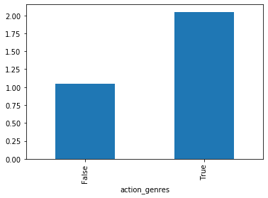

```python
#action = df.genres.str.split("|", n=10, expand = True)
action = df.genres.str.find('Action') >= 0
action
df["action_genres"] = action
actiont = action == True
actionf = action == False
#df.head()
df.groupby('action_genres').popularity.mean().plot(kind='bar');
```

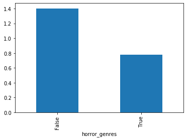

```python
horror = df.genres.str.find('Horror') >= 0
df["horror_genres"] = horror
horrort = horror == True
horrorf = horror ==False
df.groupby('horror_genres').popularity.mean().plot(kind='bar');
```

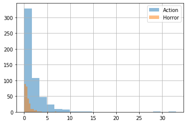

```python
import matplotlib.pyplot as plt
df.popularity[actiont].hist(alpha=0.5, bins=20, label='Action')
df.popularity[horrort].hist(alpha=0.5, bins=20, label='Horror')
#df.horror_genres[horrort].hist(alpha=0.5, bins=20, label='Horror')
plt.legend();
```

### Research Question 2 (Relation between budget and vote average)

```python
vmean = df.vote_average.mean()
vmean

high = df.vote_average >= vmean

df['high_vote'] = high
hight = high == True
highf = high == False

df.high_vote.value_counts()
```

```
True     1053
False     939
Name: high_vote, dtype: int64
```

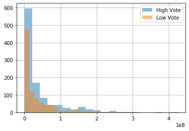

```python
df.budget[hight].hist(alpha=0.5, bins=20, label='High Vote')
df.budget[highf].hist(alpha=0.5, bins=20, label="Low Vote")
plt.legend();
```

```python
df
```

[output not shown]

1992 rows × 24 columns

## Submitting your Project

> Before you submit your project, you need to create a .html or .pdf version of this notebook in the workspace here. To do that, run the code cell below. If it worked correctly, you should get a return code of 0, and you should see the generated .html file in the workspace directory (click on the orange Jupyter icon in the upper left).

> Alternatively, you can download this report as .html via the **File** > **Download as** submenu, and then manually upload it into the workspace directory by clicking on the orange Jupyter icon in the upper left, then using the Upload button.

> Once you've done this, you can submit your project by clicking on the "Submit Project" button in the lower right here. This will create and submit a zip file with this .ipynb doc and the .html or .pdf version you created. Congratulations!

[output not shown]

```python
from subprocess import call
call(['python', '-m', 'nbconvert', 'Investigate_a_Dataset.ipynb'])
```

```
0
```